# Project: Correlation between GdP and democracy with expend in military and health, suicide level and sugar consuption between 1995 to 2010 with focus on outler countries

### Research Question 2 (Have the democracy along the period influence the expend in military and health, suicide level and sugar consuption? General world view and focus on countries with higher positive or negative correlation (over 0.8 and below -0.8))

#### Q2.1. Correlation between democracy and military expend

```
democracy vs Military expend yearly correlation details:
The correlation over  0.8 is: 0 %
Number of  years  over  0.8 is: 0
The correlation below  0.2 is: 100 %
Number of countries below   0.2 is: 16
```

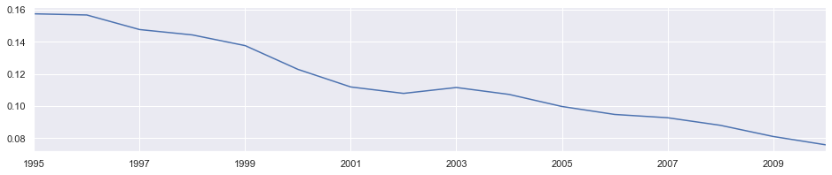

```python
# # democracy vs Military expend time evolution correlation view
print( 'democracy vs Military expend yearly correlation details:')
plt.figure(figsize=(16,3))
percentaje ((democracy_f.corrwith(military_f, axis=0, method="pearson")),0.8, 0.2,  'years')
(democracy_f.corrwith(military_f, axis=0, method="pearson")).plot(kind='line')
```

```python
# democracy vs Military expend contry correlation view:
print( 'democracy vs Military expend correlation country view:')
#plt.figure(figsize=(16,4))
percentaje ((democracy_f.corrwith(military_f, axis=1, method="pearson")), 0.8, -0.8, 'countries')
#(democracy_f.corrwith(military_f, axis=1, method="pearson")).plot(kind='bar')
```

```
democracy vs Military expend correlation country view:
The correlation over  0.8 is: 5 %
Number of  countries  over  0.8 is: 7
The correlation below  -0.8 is: 4 %
Number of countries below   -0.8 is: 5
```

> We do not observe correlation between democracy and military expend. Only 7 countries (5%) have a + correlation over 0.8 and 4% (5 countires) has a high negative correlation over -0.8 Let see if there are any country with high negative correlation We can see that there are some countries with negative correlation but below -0.8

```python
# List of countries with higher and lower correlation
print ("The 10 countries with higher correlation are:")
index((democracy_f.corrwith(military_f, axis=1, method="pearson")).sort_values(na_position="first")[-10:])
print (end)
print ("The 10 countries with negative correlation are:")
index ((democracy_f.corrwith(military_f, axis=1, method="pearson")).
                  sort_values(ascending=False, na_position="first")[-10:])
```

```
The 10 countries with higher correlation are:
Albania, Egypt, Bulgaria, Oman, Nicaragua, Algeria, Kyrgyz Republic, Chile, Bahrain, Sudan,

The 10 countries with negative correlation are:
Rwanda, Ecuador, Kazakhstan, Bolivia, Tunisia, Fiji, Czech Republic, Croatia, Belgium, Jordan,
```

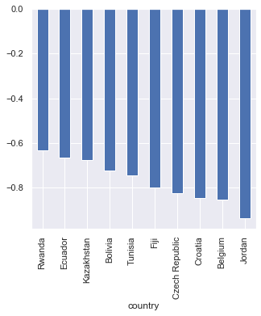

```python
# Chart of countries with lower correlation and negative correlation
plt.figure(figsize=(5,5))
(democracy_f.corrwith(military_f, axis=1, method="pearson")).sort_values(ascending=False,
                na_position="first")[-10:].plot(kind='bar')
```

#### Q2.2. Correlation between democracy and health

```
democracy vs Health expend yearly correlation details:
The correlation over  0.8 is: 0 %
Number of  years  over  0.8 is: 0
The correlation below  -0.8 is: 0 %
Number of countries below   -0.8 is: 0
```

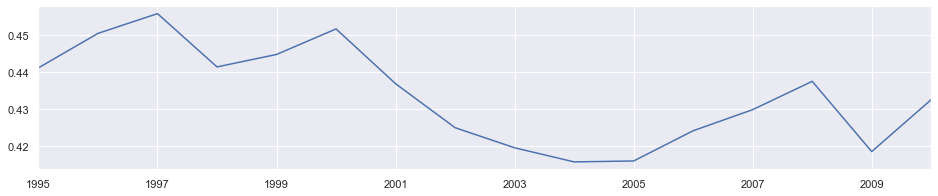

```python
# # Democracy vs Health expend time evolution correlation view
print( 'democracy vs Health expend yearly correlation details:')
plt.figure(figsize=(16,3))
percentaje ((democracy_f.corrwith(health_f, axis=0, method="pearson")),0.8, -0.8,  'years')
(democracy_f.corrwith(health_f, axis=0, method="pearson")).plot(kind='line')
```

```python
# democracy vs Military expend contry correlation view:
print( 'democracy vs health expend correlation country view:')
#plt.figure(figsize=(16,4))
percentaje ((democracy_f.corrwith(health_f, axis=1, method="pearson")), 0.8, -0.8, 'countries')
#(democracy_f.corrwith(health_f, axis=1, method="pearson")).plot(kind='bar')
```

```
democracy vs health expend correlation country view:
The correlation over  0.8 is: 9 %
Number of  countries  over  0.8 is: 12
The correlation below  -0.8 is: 3 %
Number of countries below   -0.8 is: 4
```

> We do not observe correlation between democracy and health expend. We investigate over the countries with higher and lower correlation. We see that the postive and negative correlations are mainly below 0.8 (absolute value), but for 12 countries the values are higer than 0.8 and for 4 lower than -0.8

```python
# List of countries with higher and lower correlation
print ("The 10 countries with higher correlation are:")
index((democracy_f.corrwith(health_f, axis=1, method="pearson")).sort_values(na_position="first")[-12:])
print (end)

print ("The 10 countries with higher negative correlation are:")
index ((democracy_f.corrwith(health_f, axis=1, method="pearson")).
                     sort_values(ascending=False, na_position="first")[-4:])
```

```
The 10 countries with higher correlation are:
North Macedonia, Albania, Nicaragua, Bulgaria, Sudan, Congo, Dem. Rep., Kyrgyz Republic, Bahrain, Ghana, Chile, Burundi, Uganda,

The 10 countries with higher negative correlation are:
Jordan, Fiji, Tunisia, Czech Republic,
```

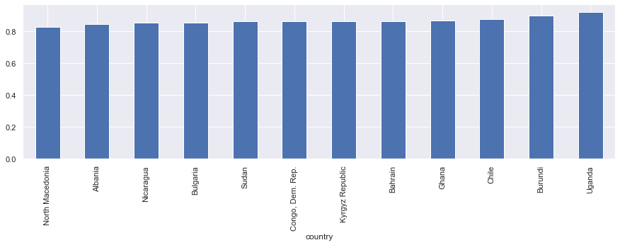

```python
# Chart of countries with high positive correlation
plt.figure(figsize=(15,4))
(democracy_f.corrwith(health_f, axis=1, method="pearson")). sort_values(na_position="first")[-12:].plot(kind='bar')
```

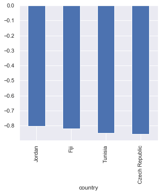

```python
# Chart of countries with high negative correlation
plt.figure(figsize=(5,5))
(democracy_f.corrwith(health_f, axis=1, method="pearson")).sort_values(ascending=False,
                na_position="first")[-4:].plot(kind='bar')
```

#### Q2.3. Correlation between democracy and sugar per person

```
democracy vs sugar per person yearly correlation details:
The correlation over  0.8 is: 0 %
Number of  years  over  0.8 is: 0
The correlation below  0.2 is: 0 %
Number of countries below   0.2 is: 0
```

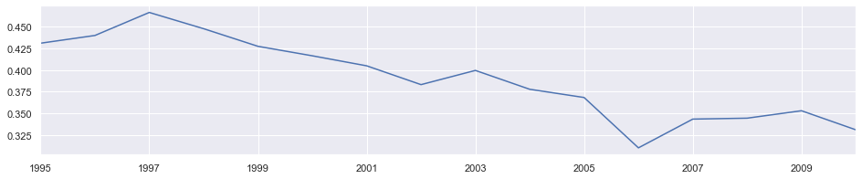

```python
# # democracy vs sugar per person time evolution correlation view
print( 'democracy vs sugar per person yearly correlation details:')
plt.figure(figsize=(16,3))
percentaje ((democracy_f.corrwith(sugar_f, axis=0, method="pearson")),0.8, 0.2,  'years')
(democracy_f.corrwith(sugar_f, axis=0, method="pearson")).plot(kind='line')
```

```python
# democracy vs sugar per person country correlation view:
print( 'democracy vs sugar expend correlation country view:')
plt.figure(figsize=(16,4))
percentaje ((democracy_f.corrwith(sugar_f, axis=1, method="pearson")), 0.8, -0.8, 'countries')
#(democracy_f.corrwith(sugar_f, axis=1, method="pearson")).plot(kind='bar')
```

```
democracy vs sugar expend correlation country view:
The correlation over  0.8 is: 3 %
Number of  countries  over  0.8 is: 4
The correlation below  -0.8 is: 1 %
Number of countries below   -0.8 is: 2
```

> We do not observe correlation between democracy and sugar per person. Only 4 countries has a positive correlation over 0.8 and only 2 have a negative correlation (-0.8)

```python
# List of countries with higher and lower correlation
print ("The 30 countries with higher correlation between democracy and sugar are:")
democracy_sugar_hc=index((democracy_f.corrwith(sugar_f, axis=1, method="pearson")).
                   sort_values(na_position="first")[-30:])
print(democracy_sugar_hc)
print ("The 30 countries with lower correlation between democracy and sugar are:")
democracy_sugar_lc=index ((democracy_f.corrwith(sugar_f, axis=1, method="pearson")).
                    sort_values(ascending=False, na_position="first")[-30:])
print(democracy_sugar_lc)
```

```
The 30 countries with higher correlation between democracy and sugar are:
Russia, Sierra Leone, Paraguay, Botswana, Angola, Morocco, Armenia, Algeria, Albania, South Korea, Moldova, Mexico, Bulgaria, Kyrgyz Republic, Lesotho, Cape Verde, Croatia, Georgia, Ghana, Ecuador, Nicaragua, Estonia, Uganda, Czech Republic, Nigeria, Bolivia, Argentina, Oman, Peru, Sudan, None
The 30 countries with lower correlation between democracy and sugar are:
Poland, Rwanda, Belgium, North Macedonia, El Salvador, Malaysia, Madagascar, Belarus, Mali, Djibouti, Venezuela, Azerbaijan, Zimbabwe, Nepal, Tajikistan, Bangladesh, Ukraine, Dominican Republic, Niger, Indonesia, Jordan, Israel, Fiji, Gambia, Senegal, Egypt, Iran, Thailand, Kazakhstan, Tunisia, None
```

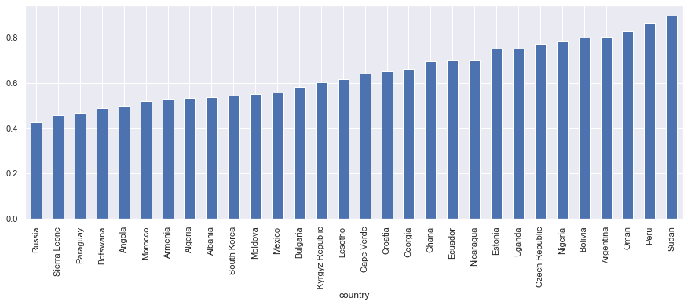

```python
# Chart of countries with high positive correlation
plt.figure(figsize=(15,5))
(democracy_f.corrwith(sugar_f, axis=1, method="pearson")).sort_values(na_position="first")[-30:].plot(kind='bar')
```

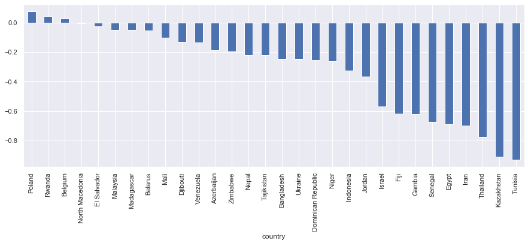

```python
# Chart of countries with high negative correlation
plt.figure(figsize=(15,5))
(democracy_f.corrwith(sugar_f, axis=1, method="pearson")).sort_values(ascending=False,
                na_position="first")[-30:].plot(kind='bar')
```

#### Q2.4. Correlation between democracy and suicide

```
democracy vs suicide expend yearly correlation details:
The correlation over  0.8 is: 0 %
Number of  years  over  0.8 is: 0
The correlation below  -0.8 is: 0 %
Number of countries below   -0.8 is: 0
```

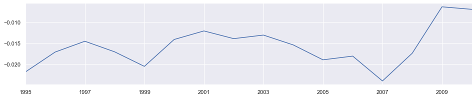

```python
# # Democracy vs Suicide time evolution correlation view
print( 'democracy vs suicide expend yearly correlation details:')
plt.figure(figsize=(16,3))
percentaje ((democracy_f.corrwith(suicide_f, axis=0, method="pearson")),0.8, -0.8,  'years')
(democracy_f.corrwith(suicide_f, axis=0, method="pearson")).plot(kind='line')
```

```python
# democracy vs suicide expend contry correlation view
print( 'democracy vs suicide expend correlation country view:')
#plt.figure(figsize=(16,3))
percentaje ((democracy_f.corrwith(suicide_f, axis=1, method="pearson")), 0.8, -0.8, 'countries')
#(democracy_f.corrwith(suicide_f, axis=1, method="pearson")).plot(kind='bar')
```

```
democracy vs suicide expend correlation country view:
The correlation over  0.8 is: 11 %
Number of  countries  over  0.8 is: 15
The correlation below  -0.8 is: 5 %
Number of countries below   -0.8 is: 7
```

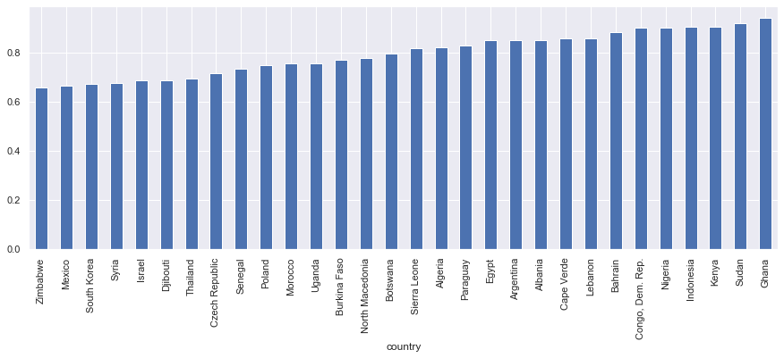

```python
# Chart of countries with high postive correlation
plt.figure(figsize=(15,5))
(democracy_f.corrwith(suicide_f, axis=1, method="pearson")). sort_values(na_position="first")[-30:].plot(kind='bar')
```

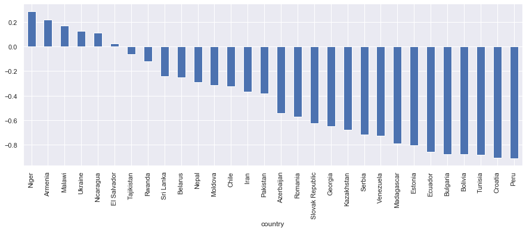

```python
# Chart of countries with high negative correlation
plt.figure(figsize=(15,5))
(democracy_f.corrwith(suicide_f, axis=1, method="pearson")).sort_values(ascending=False,
                na_position="first")[-30:].plot(kind='bar')
```

```python
print ("The 10 countries with higher positive correlation between democracy and suicide are:")
democracy_suicide_hc=index((democracy_f.corrwith(suicide_f, axis=1, method="pearson")).
                   sort_values(na_position="first")[-10:])
print(democracy_suicide_hc)

print ("The 10 countries with higher negative correlation between democracy and suicide are:")
democracy_suicide_lc=index ((democracy_f.corrwith(suicide_f, axis=1, method="pearson")).
                    sort_values(ascending=False, na_position="first")[-10:])
```

```
The 10 countries with higher positive correlation between democracy and suicide are:
Albania, Cape Verde, Lebanon, Bahrain, Congo, Dem. Rep., Nigeria, Indonesia, Kenya, Sudan, Ghana, None
The 10 countries with higher negative correlation between democracy and suicide are:
Serbia, Venezuela, Madagascar, Estonia, Ecuador, Bulgaria, Bolivia, Tunisia, Croatia, Peru,
```

> There is only 11% of the countries (15 countries) with a positive correlationover 0.8 and only 5% with a negative correlaton over -0.8

> We could not say that democracy and suicide has a direct correlation, in any case for some countries there is a strong positive correlation and for others storng negative.

## Conclusions

> Q1. Have GbP along the period influence the expend in military and health, suicide level and sugar consuption? General world view and focus on countries with higher positive or negative correlation (over 0.8 and below -0.8) We observe that 88% of the countries has a positive correlation over 0.8 with health expend and that 62% of the countries has a postive correlation over 0.8 with military expend. We could say that there is some correlation between suicide and GdP as 49% of the countries has a positive correlation over 0.8. On the other hand, 22% of the countries show a negative correlation (over -0.8) between suicide and GdP. GdP and sugar show low correlation positive (21% over 0.8) or negative (7% over -0.8)

> Conclussion: The anlyses of the GdP and Democracy correlations shows that is more pausible that GdP have influence on Military and health expend than democracy. On top, GdP evolution along the period is wider than Democracy evolution

> The main challenge of this investigation has been the data quality in the sense of there are many missing values

> I have discover that sugar per person increase all that period, I was convinced we consume less sugar at the beginign of 21st century than in the 90ths.

> Regarding GdB it was great to see that we increase all around the world and not only some countries

> Being my first contact with Python and data analysis, I have learn a lot about dataframe managing and analysis as well as visual management of information.

> I have spend a lot of time reading other people contributions and questions on stack overflow

> I have got inspiration and answer to some coding questions in these pages

https://github.com/alankashiwa/investigate-gapminder-dataset/blob/master/investigate-gapminder-dataset.ipynb

http://htmlpreview.github.io/?https://github.com/latinacode/Investigate-a-Dataset/blob/master/investigate-a-dataset-Socio-demographic-variables-resubmit.html

https://medium.com/@namnguyen168/gapminder-data-how-has-the-world-changed-for-200-years-2577633284fc

https://github.com/lukes/ISO-3166-Countries-with-Regional-Codes/blame/master/all/all.csv

https://christinalk.github.io/python-novice-gapminder-custom/aio/

https://matplotlib.org/gallery/lines_bars_and_markers/masked_demo.html#sphx-glr-gallery-lines-bars-and-markers-masked-demo-py

https://datacarpentry.org/python-ecology-lesson-es/02-starting-with-data/

https://www.pythond.com/20594/seleccionando-multiples-columnas-en-un-dataframe-de-pandas.html

https://jefflirion.github.io/udacity/Intro_to_Data_Analysis/Lesson2/Lesson2.html

https://realpython.com/pandas-read-write-files/

https://pandas.pydata.org/pandas-docs/stable/reference/api/pandas.Index.difference.html

https://stackoverflow.com/questions/43311555/how-to-drop-column-according-to-nan-percentage-for-dataframe

https://stackoverflow.com/questions/29530232/how-to-check-if-any-value-is-nan-in-a-pandas-dataframe

https://stackoverflow.com/questions/14247586/how-to-select-rows-with-one-or-more-nulls-from-a-pandas-dataframe-without-listin https://realpython.com/pandas-read-write-files/

https://www.analyseup.com/python-data-science-reference/pandas-exploring-data.html

https://jakevdp.github.io/PythonDataScienceHandbook/04.01-simple-line-plots.html

```python
#from subprocess import call
#call(['python', '-m', 'nbconvert', 'Investigate_a_Dataset: GdP, democracy and others.ipynb'])
```

```python
from subprocess import call
call(['python', '-m', 'nbconvert', 'Sugar, suicide and money.ipynb'])
```

```
0
```